# Report on Survey among Students of Cognitive Science / Computing

Michael Franke, Kristina Kobrock, Laura Krieger, Sarah Neuhoff, Alessandro Schlott, Leon Schmid, Lea Tiyavorabun and Benjamin Werk

The students of Cognitive Science (BSc, MSc) and Cognitive Computing (MSc) were invited to take part in a voluntary online survey to be completed between June 11th and June 16th of 2020. The survey was hosted on Google Forms. All data was handled anonymously. The survey can be inspected [here](https://forms.gle/vf6w6rCUeAxPXbjM9). Participation in the survey was elicited by an email to “studall” which also contained information on where to find help with various problems.

The goal of this initiative was to obtain feedback from our students on:

- how they experienced the “digital” summer term 2020 so far
- in particular, which problems and obstacles were encountered
- how, based on these experiences, digital teaching can be improved in the future

In the following we descriptively reproduce the results from all the questions asked with little interpretation or redaction. Only few comments to open-ended questions were removed in case they targeted specific courses or persons.

Cheers to everyone who participated in this survey and many thanks also to the volunteers who helped in the creation of the survey and the data analysis. In alphabetical order the contributors were: Michael Franke, Kristina Kobrock, Laura Krieger, Sarah Neuhoff, Alessandro Schlott, Leon Schmid, Lea Tiyavorabun and Benjamin Werk.

# 1. Mood and Impression

The first part of the survey asked for general mood and impressions. It asked the questions:

> Compared to the last one, how does your first digital semester work for you so far regarding your …
> - … **studies**?;
> - … general **mood**?;
> - … **expectations** (worse/better than expected)?

Answers could be given on a 10-point Likert scale ranging from 1 (= sad smiley) to 10 (= happy smiley). The distribution of answers is shown below.

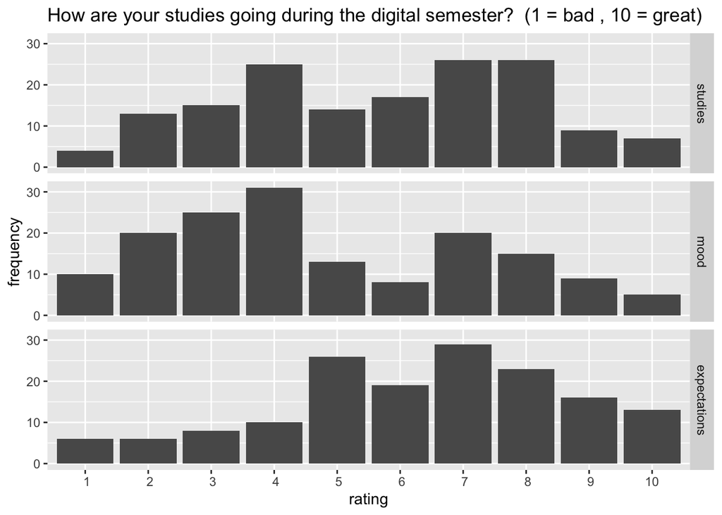

We also provided room for open feedback:

> If you want to name reasons for the above, please drop a line.

Here is what was submitted:

1. It’s very, very different depending on the course. Some lecturers are doing great things (especially ECRs!) and some are doing the absolute minimum and it just doesn’t work at all.
2. Studying is much more than just my studies. Not being able to see my friends, do sports, do all the nice Coxi activities etc. takes away the best parts of being a student.
3. Not being able to see friends at uni is really annoying
4. Self Motivation is a hard thing theses days.
5. More encouragement to -actively- engage with other students by reaching out.
6. Uncertainty about missing information about exams and other “Prüfungsleistungen”
7. I really like how everyone tries to create a feeling similar to in person lectures and seminars, but I’m missing in-person interaction during and after lectures. Watching the computer screen all day long is really tiering.
8. It’s difficult to study in a disciplined manner and staying focused for long periods of time at home.
9. … regarding your general mood: lack of social life
10. I find studying at home a lot more difficult than at uni
11. Self organizing is even harder than before, but being more flexible (no fixed lecture times) allows new free time activities. Things are still better than expected.
12. I appreciate being able to work from home.
13. I think the main reason my mood is affected is the missing social interaction
14. Less appointments-> less stress
15. I was surprised with how good BBB is.
16. Only participate in one lecture, which is a pretty nice lecture, but my overall mood overshadows the nice lecture
17. There is no space between working space and private life anymore. The “fun things” about Uni are completely missing, the small things like eating together or enjoying the sun infront of the cafeteria, basically there is no social interacting anymore.
18. I really miss to learn in small groups together and i miss to go to tutorials. If you are actually in the same room as the tutor, it is far easier to ask everything and to make clear where the problem lies.
19. digital study environment, structure, own organization, stress and worries (financial, general)
20. I miss social interactions - especially meeting people randomly on campus, the typical university life, regular classes, the cafeteria and cogsci events.
21. no major problems have arised other than maybe the timing of the soon to be compensatory exams from last semester
22. There is (was) no progress due to not being able to write my thesis before the math and informatics exam
23. Self-organizing even more than usual makes it easier to manage time (and brain power)
24. It is much more difficult to stay disciplined, and to stay up to date with important information
25. A few classes are way more complicated than they should be. It is quite annoying if the lecturer doesnt really care about how the material is given to the students. There are some classes who do an excellent job. I especially like how (e.g. in theoretische informatik) courseware is used to divide lectures into topics, instead of 90min. each and how the lecturer also used a whiteboard in addition to the slides to explain the material. But other lectures are just so bad, the audio is hardly to understand, the slides are cut off, the lecturer refers to “as you can see here”, but you cannot see where he is pointing at, lectures are missing and the slides aren’t really comprehensible without good explanation, etc. And that makes it actually really hard and demotivates a lot. You need to invest so much more time into the course and it is quite annoying that you know, that just with a little effort by the lecturer it could be so much easier for the student. Everyone needs to get used to that new format, and first has to put some work into it, students and lecturers equally. - Another point are the exams, it is almost end of the semester, but for some classes there is still absolutely no information about the exams, the only information you get is, we dont know yet. That definitely is a stressing point for me. And also in one class an online exam just got explained and the concept of that for me personally sounds really stressful and i would prefer a normal exam 10000 times over that online exam, having to put a camera in my room and personal space, stressing out if the internet connection might resists and so on…
26. I really miss the people and realize how much easier it was to keep up with the schedule, when you are on campus surrounded by other motivated people.
27. clearer communication of course requirements
28. I’m an introvert and I’m enjoying not being forced to have that much of real-time and also face-to-face conversation with others.
29. problem with concentration at home
30. Not being able to attend classes is currently not sufficiently compensated by the oftentimes subpar video recordings and online organisation of the online classes this semester.
31. Getting help via the Forum or other online ways isn’t always easy. I’m missing the support of people I normally would get to know/meet face to face in the lecture room.
32. Some courses do (way) better than expected, some do really really bad…
33. The social isolation is affecting my mood and it is very hard for me to motivate myself enough to get all the work done at home. I’m really missing a place like the university rooms or the library to focus solely on learning.
34. In the beginning, I expected that I actually get along well in this semester, because I save time by only having to watch a lecture once because in other semesters it often happened that I chatted with friends in lectures and had to revisit it at home. But now I struggle to sometimes even get up to watch it because I cannot look forward to seeing my friends there. And it’s much easier to get lost.
35. less “pressure” to actually get up early and attend lectures since almost all can be watched later on in the form of recordings
36. I feel like the workload for seminars increased heavily
37. Without any appointments or timelines, it is hard to plan your day and to find motivation.
38. Since I can hardly concentrate in a full lecture hall, I‘m glad to be able to study in an environment that fits me best. I also appreciate the flexibility of studying online. But: missing personal contact has a huge psychological impact, especially if you live alone; generally, those who can’t study with peers have a disadvantage, it makes things much harder.
39. For me the issue is not that the workload over all das increased. What hab ne exhausting is to bring up the additional energy for the self organisation aspect of this semester. If you can only study from home there is no barrier between studying and relaxation and you are never really done.
40. I wouldn’t consider studying during corona as real studying, it’s rather a ‚Fernstudium‘. I decided to study because I was not only interested in the courses, but also to get in touch with likeminded people to create a network. During corona that’s definitely not possible.
41. General mental health struggles, that have increased due to the intense work load of online courses and the thereby caused decreased amount of courses I can manage.
42. Not all courses are good modeled for online study
43. since it is possible to connect with a few people I really like the online semester and have some advantages, fpr example I can work during the week and study in my own pace
44. Initially I thought this semester was going to be an advantage and I was gonna be able to focus on learning more than I did in the previous semester. I thought that by having digital access to all lectures and material would allow me to focus on that and not having to deal with going to the university in person and waste time while enrolling in casual conversation with others would be an advantage. I personally manage very well self learning and during the summer break I had the change to experience it while doing computational pragmatics. The course was well structured and the video explanations and material was well organized. However, this is not the case for most subjects and that is surprisingly overwhelming for me since we (the CogSci) are suppose to deal with technology or virtual platforms all the time. Not all the professors are prepared for moving into digitalization (I think nobody was -including us, students). I think since we are using digital material, just a 2 hours video lecture and 60-80 slides will not be very helpful. That we should know from psychology, attention does not last that long– and given there is not interaction, things are more complicated. Therefore, virtual learning platforms demand interactivity (e.g., answer a question in between video, solving x or w task etc.) something that motivates me to keep looking and feeling I follow the professor. Finally, I think there is a delay nobody is considering .. from the time professors do recordings and us watch the videos. One can easily spend one full day just trying to find put the material on StudIp and watching videos for both… lectures and practice sessions. So, if I class on Monday 10-12 but at that moment there is not video because it is being recorded, then I have to move all my plans and work on that later in the week… aaah but true, the homework is still for the end of the week.
45. Staying home can be exhausting, although I enjoy the flexibilty
46. It is boring to learn at home
47. I really miss discussing the lectures with other students, it gives me much more motivation to follow the content, helps me to understand and last but not least contributes a lot to my social wellbeing.
48. I am having a hard time this semester for two major reasons: first, each day it is getting harder to work in the same little space all over again, as in a WG you do not really have any room to move around or find a different scenery even just for a minute. It would be helpful, if the library was open to study in again. The second reason being, that obviously it is expected of you to have a working and fast WiFi connection. However, mine is currently having issues and I am often kicked out of BBB meetings due to this or having to wait ages for say OpenCast to play a video. Again, opening the libraries would be helpful here.
49. Most annoying is that you can’t print on campus and that you can’t study in the library
50. Less possibilities to interact / work togehter with other students, less productive working at home
51. Professors did a great job of switching their “ways” very rapidly. The lectures are very well structured and contrary to the “old” lecture, I can rewatch something if I missed it. I would even say this semester has been better than the last in terms of content and personal time management.
52. No longer taking classes (credits are full) and only working on thesis research = complete isolation at home with very few interactions with fellow students (which have been facilitated by attending classes/eating at the mensa in past semesters)
53. You can take courses that would otherwise take place at the same time, and in general manage your own schedule better.
54. I am currently only writing my Bachelor’s thesis, thus I do not participate in any courses (the only one I wanted to take this semester was dropped, sadly). I rely on lab equipment, but we made it work, so the situation is better than expected.
55. Working from home I can’t motivate myself as much as when I’m in the university surrounded by fellow students. Also being in the flat really invites procrastination.
56. This format makes it possible to attend events you would otherwise be not able to take part in (like virtual scientific conferences etc), and our institute does a great job at switching almost all the classes I take to a virtual format. You can also attend otherwise verlapping classes.
57. The online teaching methods (BigBlueButton) work quite well, even discussions work if people are motivated
58. What is particularly problematic for me is the lack of possibilities to study outside home as all universities buildings are closed.
59. I save time by having online courses and understand the contents better because I can have my own pace. It works much better than a normal semester for me.
60. Its nice to have your own sleeping cycle, but studying together is more fun in person
61. it’s so boring and sad to sit in front of the computer and do everything like that. I quite miss my fellow students and Frosch and the Cafeteria and the people working at the campus Westerberg.
62. Most courses run surprisingly smoothly and I even feel like my studying and general stress level has profited a bit (no “lost time” on physically getting to uni for example). The almost completely removed social aspect does take its toll though.
63. since you cant do anything else anymore, I decided to take a hella lot of courses which I consider cool. I love the courses, so regarding studies - this semester is going quite well. Miss having other people around while working though. It is much harder to stay motivated when there is no one else physically around, working as well.
64. i’m in pakistan and this is my first semester. U Osnabrueck, as of now, is merely coursera to me. i am genuinely impressed by how well this semester has been executed. however, i do think about what i’m missing out on by not interacting with my college mates
65. Die durchgehende Prüfungssituation im Semester mit den Hausaufgaben ist eine starke Belastung. Die durchgehende Prüfungssituation entsteht durch die vielen Präsentationen und Projekt im Semster, die auf Grund der Digitaliserung gemacht wird

# 2. What works well online? What doesn’t?

In this section we were are asking for the students experience with the online semester, in particular with different formats of teaching, learning etc.

## Rating scale answers

First participants were asked to indicate how much they agree with the following statements with the ongoing semester in mind on a 10-point Likert scale ranging from 1 (= I do not agree) to 10 (= I agree):

> The online format works well for …
> - **lectures** (lecturer presents information)
> - **tutorials** (teacher presents and discusses exercises and solutions)
> - **“Testate”** (students present homework to e.g. research assistant)
> - **small seminars** (<= 15 students)
> - **large seminars** (>15 students)
> - listening to **presentations**
> - **reading clubs**
> - **study projects**
> - solving homework **exercises** in student groups
> - working on **group projects** (papers/presentations…)
> - working as a **HiWi**
> - participating in **extracurricular activities** (e.g. student body, university politics)
> - managing general **administration** tasks (e.g. examination office)

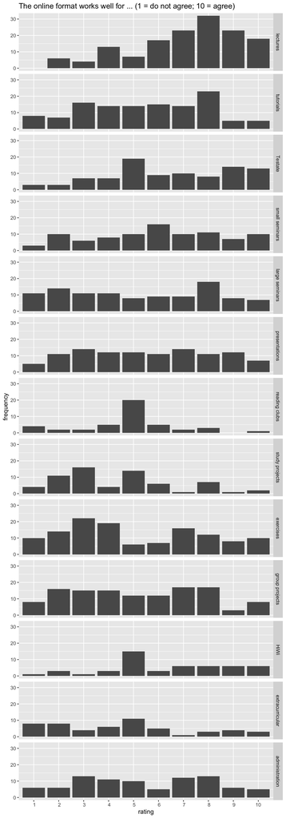

## Free text answers

When asked whether they want to add something specific about the parts of online university that work well or not so well or if they have suggestions on how to improve the shortcomings of specific types of sessions the students answered freely. The number in front of the quotes represent the participant number. The quotes are sorted according to their topic. Within the blocks the first part are additions to the question “What works/What doesn’t?”, the latter part are suggestions to improve the shortcomings. Hence, when a participant answered both, their number appears two times. Spelling was not corrected. When sensible a rough Recap is added to summarise the results, sorted according to the number of students mentioned an issue/suggestion

### Lectures

1: Some courses […] don’t offer tutorial/practice session at all.  
2: the big blue button channel works great for lectures but not really for tutorials.  
3: Tutorials are not always given.  
4: Lectures are missing and the content isn’t well transmitted through online lectures. Currently I’m learning solely by books and the web. I would like to have at least some guidance from our lecturer on where to look for information or which content should be looked at more closely.  
5: It is annoying when video recordings etc. are uploaded unreliable (e.g. one week on monday and the other on thursday), that makes it hard to create oneself a fixed time schedule.  
6: Some classes are not well adapted to total virtual platforms. The classes are basically composed of a almost 2 hours video and 60-80 slides. That’s all. Given classes are online. then the strategy should be a different one. I would rather watch a 20 minutes video explaining straight away what is important and answer some questions in between. and then spend the rest of the time researching for answering some extra question the professor formulates than just passively listening him talk  
7: I don’t think online lectures work well as the uploaded videos often have a very bad quality or are even missing. In addition to that it is also harder to ask the lecturer questions, as they often don’t offer QA sessions.  
8: communication especially regarding the exams, also from WS19/20.  
9: The quality of the lecture strongly depends on the motivation of the lecturer to make the lecture work.  
10: More Live Streams would be appreciated.  
11: If online lectures work is dependent in the lecturer. It can be frustrating, when lectures do not upload their material in time since this can disrupt the study Plan that one has created quite a bit. The quality of the online presentation in most lectures exceeds expectations  
12: Whether online classes (lecturer presents information) work well depends completely on how it is done: Just doing a regular lecture and recording it is not really helpful, but they are exhausting. Doing those live, with us having to attend, is even worse. Really making use of the available digital means is awesome, though; e.g. short pod- and/or screencasts, a well balanced mix of online tutorials and reading assignments, even VIPS can be really great.  
13: I am positively suprised how well the Testate are going.  
14: Trying to improve the actual passive 2 hours video-slide format of the lectures would be a great start.  
15: Eventhough the online format suits the lectures, the quality of the resulting programs varies. E.g. it would be beneficial if lecturers adjusted their style for prerecorded lectures. Since we do not see each other in person, the (in my opinion silly) pressure to avoid just reading off of a script is non-existant. I’d much prefer you reading a script if it meant that the information was conveyed in a more concise way. At least one lecturer appears to utilize editing techniques in their prerecorded videos, making cuts. Whether this is to just take a break, edit out mistakes, or to select a better take, I appreciate this. I can’t reasonably expect everybody to learn about video editing, but it can significantly improve the quality of the lectures.  
16: minimum 3 weeks before announcing a exam not just 8 days (Intro to Neuro, WS19/20)  
17: Online classes work perfectly for lectures if they are recorded. It happens that there are a lot of lags to people with bad connection, especially in lectures with lots of people. So being available to watch the lecture later is a must in my opinion  
18: One professor introduced question and answer sessions every 4th week or so which made it possible to ask questions about the lectures we have heard so far. I really liked this idea to balance out the missing interaction we normally have between students and professor (i.e. if the lecture is not held online).  
19: if the lecture isnt live online, I would really recommend theme-structured videos. Makes it easier to listen and structure your study.  
20: PLEASE DON’T try to just cram physical lectures/seminars into a digital format. As stated before, there are great ways to embrace digital formats - which of course have shortcomings of their own - but please understand that it’s a different beast than regular/classical formats and thus have to be implemented differently.  
21: Especially with lectures where a lot a videos are uploaded, I find that the time requirement to work through them is a lot higher than with normal lectures. I feel like when studying from home everything takes longer than it usually does and this is not really considered 144: For lectures: I appreciate the audio files put into the presentations, I would suggest to meet via BBB every two weeks to give room for questions regarding the content (like QQ but more often and periodic)

#### Recap - Lectures

Transfer lectures 1-to-1 as online material (e.g. talking while showing slides) alone does not support the student’s learning success (3 students)  
Offering additional Question and Answer Sessions helps the students to understand the material (3 students)  
Videos and material should always be uploaded at the same time to support the students in structuring their week (3 students)  
Having shorter videos (20 min) mixed with interactive parts (e.g questions, short independent research tasks, VIPs) would be preferred (2 students)  
Having live lectures is bad, bad internet connections (either because of number of attendees or technical issues at home) make recordings necessary (2 students)  
More live streams are appreciated (1 student)  
Tutorials are sometimes missing or not offered at all (2 students)  
Spoken text accompanying the slides can be scripted (if it improves content/structure), editing (making breaks, selecting the best take) is highly appreciated (1 student)  
Structuring the videos according to their theme helps students to listen to them and structure their studies accordingly (1 student)  
Videos are better than “real” sessions because one can pause and rewind to deepen the understanding (1 student)  
Following and understanding an online lecture takes longer than the mere video length (1 student)  
Giving some hints where students can find reliable extra material on specific topics is appreciated (1 student)  
Quality of the videos is bad (1 student)  
Quality of most lectures exceed expectations (1 student)  
Communication in regard to exams (also of last semester) should be improved and exams should be announced at least 3 weeks in advance (1 student)  
Testate work well (1 student)

### Seminars

1: […] from my experience most students dont want to turn on their microphone, so no one is speaking except the tutor. people try to explain their question in the chats, which usually leads to misunderstandings.. It’s pretty exhausting.  
2: In Seminars the online format doesn’t really invite discussion that much especially because I for example don’t have a working mic or camera on my laptop so I can’t speak in discussions and will have to use my phone to record myself during presentations.  
3: I feel that when a seminar just consists of a student presentation each week (not even a discussion taking is taking place), I do not learn something. Especially when the lecturer neither provides additional content nor criticism on the presentation.  
4: Seminars are not really what they are supposed to be (at least the one I am taking at the moment) since it is mostly the professor or a student that is giving a presentation talking, but not really an active discussion between students and professor.  
5: In my opinion the most important part of a seminar is the open discussion between participants and lecturers. This is not really possible im the bbb-seminars that i have seen so far.  
6: […] I participated in a small seminar and as soon as verbal exchange start in a Zoom-session, it starts to not work smoothly. People definitely interact more dynamically in a real world setting + technological issues (that still happen) make progressing at good speeds hard.  
7: make it obligatory to speak up? one probably cant do that.  
8: Sadly not. I find it hard to discuss in a chat as one can not see the faces of the interlocutor  
9: Personal discussions and interactions are really missing, and small group assignments might be nice to compensate this.  
10: Giving students feedback about their planned presentation beforehand and afterwards would be valuable.  
11: Everything with more than 30 students as an online live session (tutorials, seminars,..) get’s a little chaotic usually, maybe have more smaller seminars? or more tutors?  
12: […] For Seminars: it would be nice to use the techniqual advantages even more - icluding videos, breakout rooms and other to higher the students engagement  
13: Create smaller seminars, splitting them into subgroups. Tutors should talk up more frequently and make sure no question is missed.

#### Recap - Seminars

Discussions are exacerbated in online seminars (either because of the setting in general or technical issues) (8 students).  
This is worsen in large seminars, hence, smaller groups are appreciated (2 students). Alternatively small group assignments could be nice to compensate this (1 student). Or make it obligatory to speak up in an discussion (1 student).  
Using more of the technical possibilities (e.g. videos, breakout rooms, other means to engage the students) would be appreciated (1 student).  
Receiving feedback before and after a planned presentation would be valuable (1 student)

### General Lectures/Seminars

1: It is incredibly hard to reach some professors, they just do not reply to emails or calls…  
2: Sometimes perhaps better prepare lecturers and tell them what (new) resources they can use.  
3: using the possibilities of the online tools, like little quizzes during a session to make it interactive for the students. […]  
4: Teach the lecturers a more extensive use of Stud.IP for setting up Lectures/Schedules/Resoruces in an organised way (E.g Courseware). Its all there, it seems like most just don’t know.  
5: Please more interactive use of the courseware (as e.g. Tobias Thelen does);  
6: […] So, what I want to say is that adding more work load to the course (in the middle of the semester) in times of online university is something that definitely does not work well.  
7: better prepare professors/lecturers for situations like these

#### Recap - General Lectures/Seminars

Prepare the teachers to make use of the resources to create interactive and organized material (e.g. Courseware, quizzes) (5 students).  
It is hard to reach some professors (1 student).  
Changing the workload during the semester is not appreciated as it deranges the planning (1 student)

### BigBlueBottom and Stud.Ip

1: The stud.ip courseware (if used well) helps to follow the red thread of a course  
2: BBB has problems in one of my courses, in otheres it works fine  
3: BBB has sometimes problems but zoom always worked also for large groups. So would be nice if BBB could also improve the quality.  
4: Add a function to raise a hand in BBB  
5: We definitely need a better online teaching/learning platform than studIP. It has a lot of limitations that hamper the whole process of effectively providing and presenting study material to the students.

#### Recap - BBB and Stud.Ip

BBB occasionally has issues to work reliably (2 students).  
Adding a function to raise a hand in BBB would be appreciated (1 student).  
If Stud.Ip courseware is used well, it helps the students to follow a course (1 student).  
There is a need for a better teaching/learning platform than Stud.Ip as it has many limitations (1 student).

### Examination Office

1: The examination office is particularly slow to respond to emails and other requests like registration of thesis, etc.  
2: Nowadays it is very difficult to reach the examination office.  
3: The Pr¨fungsamt is doing a great job!

#### Recap - Examination Office

The examination office is slow to respond or difficult to reach (2 students) and the examination office is doing a great job (1 student)

### Technical Issues

1: The well working parts depend on a good internet connection;)  
2: In general online lectures should work really well because they are often not that interactive and could easily be recorded but unfortunately in my experience the recordings often lack quality.  
3: […] Without access to university printers, printing becomes a tour de force.  
4: some professors/lecturers do not have the technical lnow-how to guarantee for example good audio quality  
5: Its difficult doing paper work, without having the possibility to use a printer. (As it is not allowed in the library)  
6: […] And if every lecturer let’s us download the content since sometimes it’s not possible for me to watch them online because of my Internet connection.  
7: […] better microphones for the lecturers (quality is often bad)

#### Recap Technical Issues

The recordings have suboptimal audio quality (2 students).  
The students internet connection is hindering them to watch the (live) lectures (2 students).  
The missing access to printers is problematic (2 students).

### Meta Critique

1: It is all very relativ.. The lectures work well compared to what? How it was before; then it is bad. How it works compared to other universities or schools: good enough. I think the problem is that this semester still counts as a normal semester (as far as I know), which is highly unfair. I would consider all of the classes much better if it would be a choice to take them.  
2: Yes, I love the fact that evaluations are getting more project-based and getting further away from tests. Tests suck! They are stressful and not that accurately representing ones’ understanding and learning of the topics. I’m so enjoying this online phase.  
3: In general Lecturers / anyone in teaching should be aware of how problematic the situation is and be careful to be *extremely* forgiving with regards to deadlines, examination strategies, etc. There many issues students have to tackle right now which might render them unable to actively take part in studying, which are not at all their fault - help these students to still be able to finish their courses.

### Homework/Projects/Presentation/General Study Organization

1: Probably the biggest problem I have this semester is homework and projects. Working together just works so much better when you sit next to each other and can see what the other person is doing. Screensharing crowds your own screen, pointing at stuff simply does not work. Also I see no alternative for this. Just sucks.  
2: I really like online presentations since one does not have to stand in front of the whole class but rather can sit at home while giving the presentation. That might be more comfortable for shy persons.  
3: Regarding presentations it is much harder to concentrate if you don’t see the presenter and also as a presenter to give a good presentation without being able to read the audience. It can be hard to find study/presentation groups if you take part in a course without knowing anyone and not being able to talk to someone in person.  
4: [..]Another thing that does not work for me online are group presentations. […]  
5: Organizationally it works really well, but it is really exhausting both on body and mind to have everything going on online.  
6: […] For homework: be more dynamic and flexible for the amount of homework, instead of having one big performance goal, use a learning goal. Studying by myself makes it easier to learn without a heavy time pressure, but I need more time for solving homeworks and preparing the material from the lectures. It is quite uncomfortable to watch at a screen for more than 6 hours a day

### Social Aspects

1: i cannot collaborate, discuss or group study with fellows. i cannot discuss my research ideas with a process if i happen to pass them by in the corridor or i see their office door open.  
2: Studying is a lot more fun and a lot more productive and creative if you have spontaneous and regular contact to other people. This is a fundamental part of research and studying that is missing totally in an online university.

#### Recap - Social Aspects

Studying, discussing, generally research is missing a fundamental part when there is no regular contact with other people (2 students).

# 3. Problems encountered during the “digital” semester

In this section we had wanted to specifically ask which (if any) problems arose for the students due to the Covid-19 crisis in general and the online semester in particular.

## How problematic was the summer term in gernal?

The question asked was:

> How problematic was the summer term 2020 for you in general?

Answers could be given on a 10-point Likert scale ranging from 1 (= very easy / no problems at all) to 10 (= very problematic / many problems). The distribution of answers is shown below.

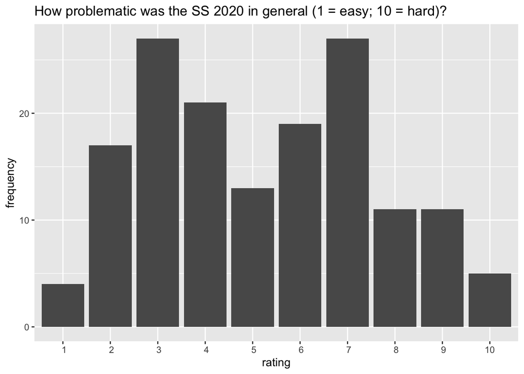

## Which issues were encountered?

The question asked was:

> Which of the following issues or problems affected you as a result of the Covid-19 crisis and/or the online semester?

This question asked for (multiple selection) of pre-given issues which students may have faced. Here’s the frequency with which each issue was selected. Note that only 14 participants indicated “no particular issue”.

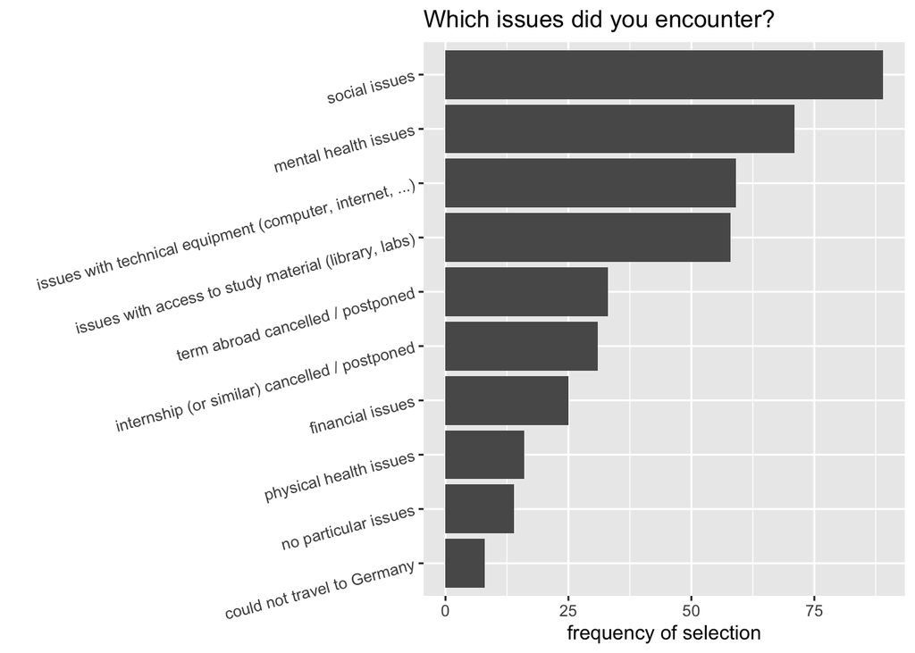

The question also allowed for specification of “other issues” unmentioned in our pre-given list. Here are the 21 issues mentioned additionally:

1. Communication with teachers/lecturers is more difficult
2. Could not participate in ultramarathon event in Switzerland
3. Daily routine is highly restricted and impaired
4. Even the post is going online now. How cool is it! I can mail my letters at home!
5. Finding a suitable working space with libraries closed and very little space at home
6. Group work and weekly assignments are much more time consuming online
7. I cannot visit my dying grandmother. Also, in my shared flat we have been the third time in quarantine
8. I had no room to study. At home or at friend’s places it is very hard to study
9. Issues with lab equipment
10. Meetings/appointments with Professors
11. No cheap Mensa food
12. Not mental health issues, but generally a bad mood/demotivated
13. Visiting home.
14. finding a way to deal with this passive format of the lectures, waiting for the lectures to be uploaded, procrastination, working in groups is the worst thing ever!, not only others are expecting you to do the HW, but also your grade depend on what they do!
15. issue of only having one room/one working place where you have to do all, therefore your recreational and your study life are not seperated at all
16. issues with exam taking
17. more lazyness
18. postpone master thesis
19. printer
20. problems with motivation
21. troubles to find a free space to study outside home

## Psychological problems

The question asked was:

> Do you suffer from any psychological conditions?

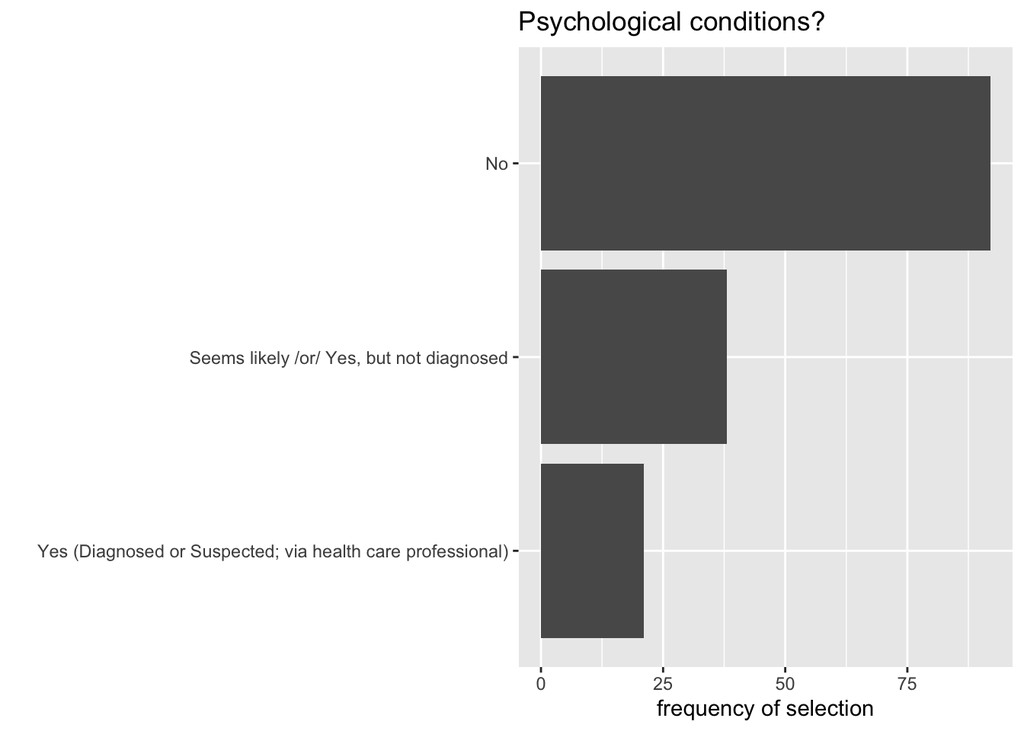

A follow-up was asked as well, namely:

> If you suffer from any psychological conditions, did your situation worsen since March 2020?

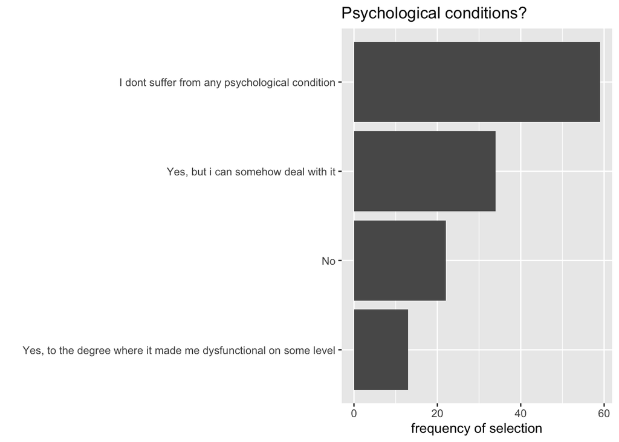

## Open question: other issues?

We also asked for any other issues to report freely:

> If you like, please tell us about any particularly striking problems that you encountered personally. If possible, please mention ways in which similar problems could be preventable or solvable for others in the future.

The answers given are listed here:

1. Suffer from tinnitus and it is made considerably worse with hours of very poor quality audio from online seminars and lectures.
2. It is really difficult to find motivation to do the self-study, in particular if there is no deadline for videos one has to watch…
3. Communication issues: I have repreatedly witnessed situations in seminars (and heard from situations in lecturs) where there have been communication issues, regarding things like deadlines, contents of presentations, etc, which under normal circumstances would probably not have happened, because people would have talked about it (this includes situations where students only get some information by ‘buschfunk’, but also situations where teachers just did not put information into slides / their talks presentations, which would still have been available because people would just have asked them after the sessions) Deadline issues: Personally and from friends i have encountered situations where their situation did now allow for them to submit homework to a deadline, for various reasons including mental health situations, not having wifi available (where normally just going to the library solves the issue, if you are not allowed to go somewhere else, what can you do?), just being overloaded with the untypical situation, having to work / apply for jobs because their job they rely on for money was cancelled due to corona, etc. Just not making deadlines that strict would have helped here, especially approving cases where the situation is unclear to the lecturer (a friend missed a deadline, the lecturer wanted explanation, but they did not want to disclose that they simply where in a fucked up financial situation due to their job being cancelled and had to struggle for a job/money for the week they had for their hw submission).
4. The daily routine during the online semester lacks social contact of any kind. Additionally, the high workload during the semester leaves little free time for the few recreational/social activities still possible.
5. I don’t have an adequate working environment; the university could offer workplaces for students, that don’ have the opportunity to create one at home.
6. Firstly to be mentioned, my problems are not as serious as the problems probably most people face right now. But for me, sharing my room´with my partner and hence also sharing the one desk is of an issue. Not personally but workwise, since he has a lot of skype/zoom conferences where he needs to talk and i am currently writing my bachelor thesis and i really need a quite place to work every once in a while which is currently not given. Also when it comes to scanning/copying I am not equipped at all, and the bibs being closed is quite a difficulty. If the bibs could reopen under strong regularzation that would be of great help for me.
7. I find it very hard to motivate myself. Normally I would be able to spatially seperate uni and free time but now I am always in the same room.
8. Missing motivation/feeling to “empty-headed” to concentrate: It helps to get properly dressed and seperate work space from relaxation space as good as possible to get into the necessary mindset when you need to focus on study work.
9. Loneliness.Isolation makes studying harder
10. I have troubles working at home productively an problems handling my workload, which causes a lot of stress. It became harder to get my head free and enjoy freetime and relax at home. Since my room is very dark I miss studying at the library or the Frosch, but due to the current situation that its not possible to open them for this pupose.
11. I had to work many hours to pay my rent and bills.I lost my previous job. Hiwi jobs could help but there are few free positions for international students and we never get informed on time.
12. Low internet connection at my family’s place (living at the countryside). I moved to Osna and had little social support here.
13. It is incredibly hard to motivate myself enough at home and without most social interactions and as someone who suffers from diagnosed depression it would be incredible helpful to have some access to some remote learning place.
14. Social isolation and the lack of a schedule was definetely a struggle in the beginning of the semester, as I felt overwhelmed with the workload. Very unhelpful was the poor organisation in one specific course (the rest was well organized and reliable), which resulted in multiple readjustments to my schedule. Organizing study meetings with other students (remote and with my flatmates) was super helpful. Because lectures and tutorials are not fixed to a time, I had trouble taking off any day for the first few weeks, because the workload literally never stopped. In that sense, finding and adjusting to a schedule that works for me was tougher, but adjusting the timing to my needs was easier. I have been diagnosed with depression and definetely felt that the isolation from a more active study life (as in going out and leaving work mentally when leaving the library) has taken its toll. I am very close to my flatmates which has helped a lot, but I am sure many other students (especially new ones) do feel isolated and alone with their struggles (the second semester was a tough one). As this probably will be going on as it is for a while, we should not forget about the ones who are alone at their desk with a lot of workload and without much experience with such situations. Online seminars which help with self organizing would be great.
15. My mother died and now my whole family life crumbles. I feel so lost and I can’t solve all the problems that burden my father. I am tired all the time
16. It feels like me study project supervisors are expecting a lot of commitment of the whole group. Sometimes I get the feeling that I signed something like a contract to be available 365 days of the year that the project lasts. Since we could not do the project as planned (due to not having access to the lab), we gained some time, but it feels like now expectations are even higher. I would hope for more patience from the side of the lecturers and more understanding that this whole situation makes learning and working a lot harder and therefore not as productive as before.
17. Missing social contact caused depressive symptoms; it is hard to admit that you get more and more dysfunctional since we’re always under pressure, and that makes even more lonely. We need a more open-minded culture about mental health issues at university (not only in Corona-times!), in a way that is not about increasing personal efficiency (what for are we doing all this?) but centers us as non-perfect human beings with needs and weaknesses.
18. social isolation and lack of networking is annoying (good that I am well connected already).
19. Just problems with motivation and keeping up with the workload.
20. The cancellation of my scholarship for both an internship and a semester aborad has left me in a state where I do not have any aim I am working towards/no plans. The impossibility to provide a good solution for postponing both has therefore been a major course for the worsened mental health. Providing motivating talks or outlooks for future possibilities (after the Bachelor) would be helpful (e.g. former Cogsci students describing there experiences).
21. being aware and acting responsible in the time when covid19 was higly dangerous. I tend to think that I do not care, because I will die someday anyway. This time it was more about helping others and not being selfish anymore. I started appreciating the little things even more and I would like to have a shut down every year.
22. The worst thing of this semester was me feeling as shit. Literarily, thinking I am the one who is wrong because I do not get to understand X or Y lecture, homework deadlines, my groups is not doing anything and I have to do most work because I want a good grade etc. Then, finally realizing that I am not understanding not because I am bad or not intelligent enough but it is the format and the (sorry to say) long-boring-passive lectures are sometimes given. I realize that it is easier and better if I just take the topic in question for the week lecture, do not spend time watching the lectures videos and just google or YouTube explanations about it. much more efficient!
23. lethargy and unable to concentrate
24. It is very stressfull to handle all the workload alone, in this home enviroment with nobody around to help.
25. It is quite distressing that there is no information when exams belonging to courses of the winter term can be carried out.
26. I am in my final semester an I could not travel to Germany on the planned date. However, administrative issues like oral exams and BSc thesis registration require a lot of paper work to be accomplished via POST - and 1) I have no access to my documents in Germany 2) even if I had them, postal services just do not work in some countries (as opposed to Europe). So a possibility to submit paperwork in digital formats would be really helpful!
27. It is quiet overcomplicated to get your transcript of records, to then send it back to get the Bafög Formblatt 5.

## Which help was made use of?

We asked:

> To cope with any arising issues, which of the following services have you used?

Participants selected from a pre-defined list (multiple selections possible), but could also indicate ‘other’:

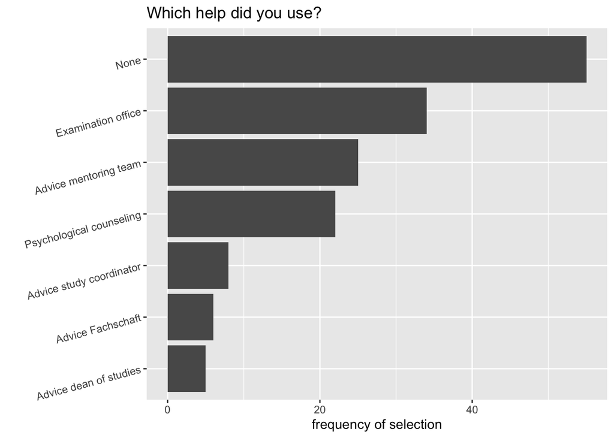

Here is are the answers given for the open question regarding which other services participants had relied on:

1. Advice fellow students
2. Friends and family
3. Google and YouTube
4. I am doing therapy, but also before the corona-shutdown
5. Oh I once contact a person for getting advice about registering my thesis which they were not helpful. But then I directly contacted the responsible person in the Prüfungsamt and then everything went well afterwards.
6. Petra Dießel, always helpful
7. Professor’s directly, because mentoring and Fachschaft did not handle the issue.
8. Supervisors
9. Tandem mentoring
10. VirtUOS
11. family
12. family and friends
13. i asked for a helper for foriegn students, however i only spoke to her over whatsapp. she helped me use studip etc
14. other students and friends
15. some but don’t know which one
16. talking to family and friends
17. talking to other students about their issues and how to deal with them - but I guess that’s obvious?
18. work as a mentor in the coxi tandem mentoring team, which gives me responsibility and social contacts

# 4. Study Load/Progress

In this section we were trying to obtain information about how “efficient” the online semester appears to be.

## ECTS point goal for this semester

We asked:

> How many ECTS points are you aiming to get this semester?"

The question asked for pre-given amounts of ECTS points student are aiming to get ranging from “less than 15 ECTS” to “more than 30 ECTS”. Here’s the frequency with which each amount of ECTS points was selected.

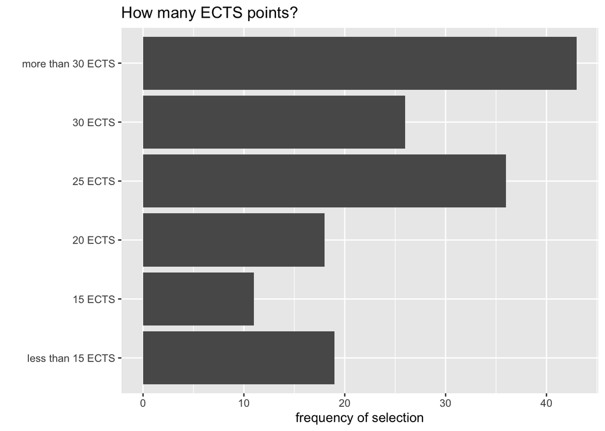

## Classes dropped

We asked:

> How many classes did you drop because of the current situation?

The question asked for pre-given amounts of dropped classes ranging from “1” to “4” and also “None” and “All”. Here’s the frequency with which each amount of dropped classes was selected.

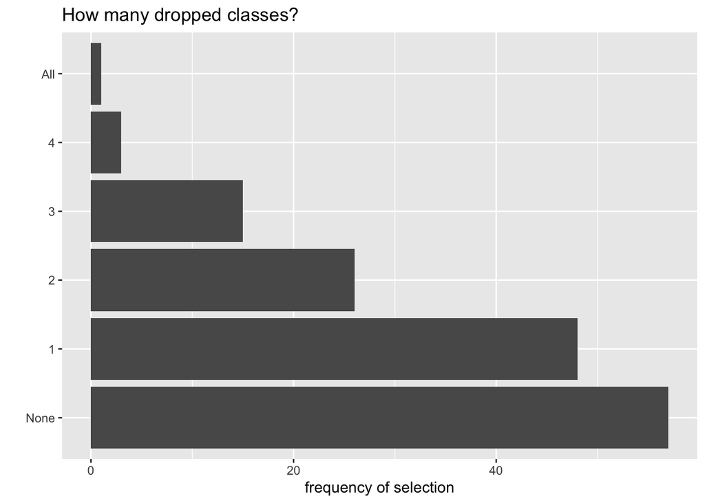

## Change of course load

We asked:

> Are you currently following more or less courses than in other semesters?

Answers could be given on a 5-point scale ranging from “much less” to “much more”. The distribution of answers is shown below.

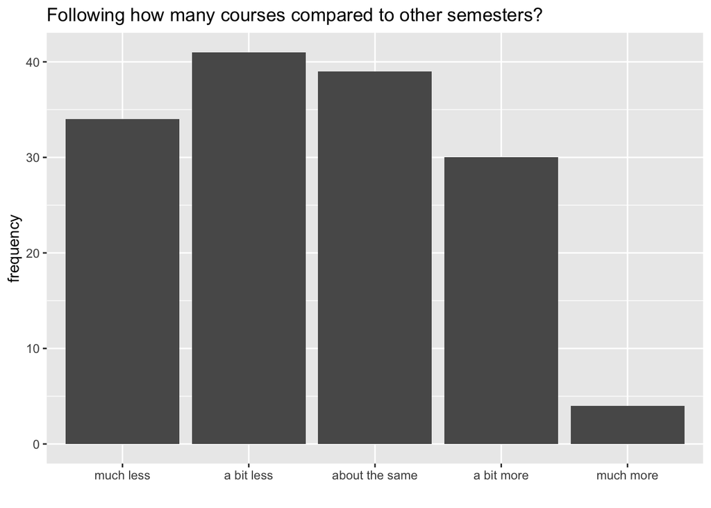

## General work load (compared to previous semesters)

We asked

> How much work are the current digital courses compared to usual university courses?

Answers could be given on a 10-point Likert scale ranging from “way less work” to “way more work”. The distribution of answers is shown below.

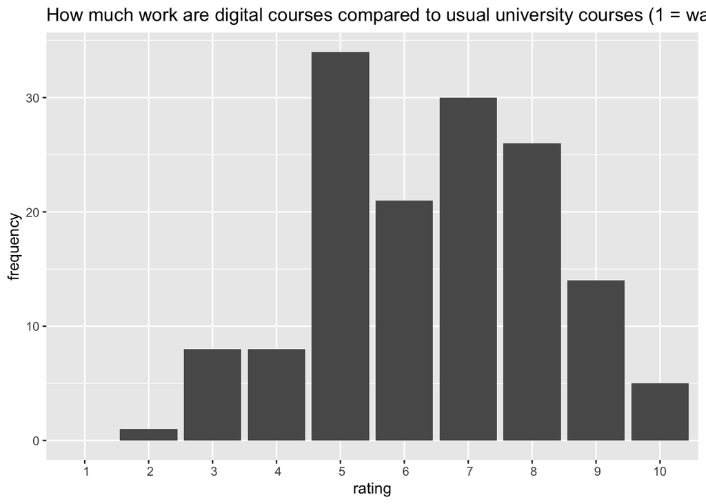

## Study delay

We asked:

> Do you think that you will need more semesters than planned to complete your studies because of Corona?

The given answer options were “No”, “Yes, one semester more” and “Yes, more than one semester more”.

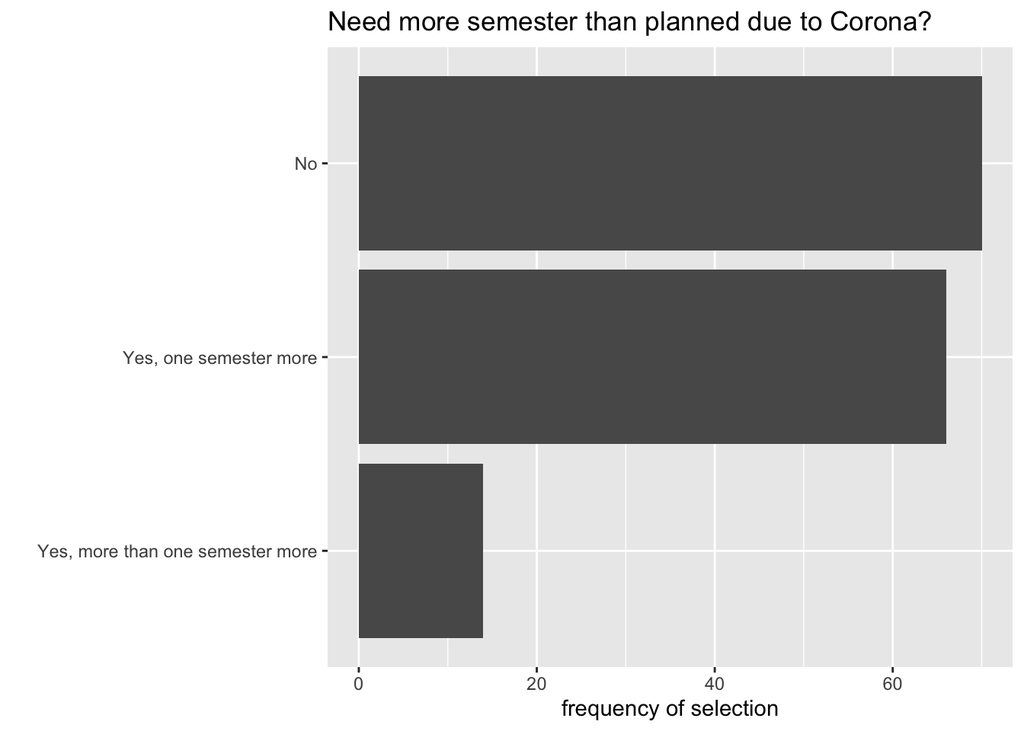

## Participation in live online lectures / seminars

We asked:

> Are you regularly taking part in lectures or seminars that are broadcasted live?

Participants could choose between the two answers “Yes” and “No”. The distribution of answers is shown below.

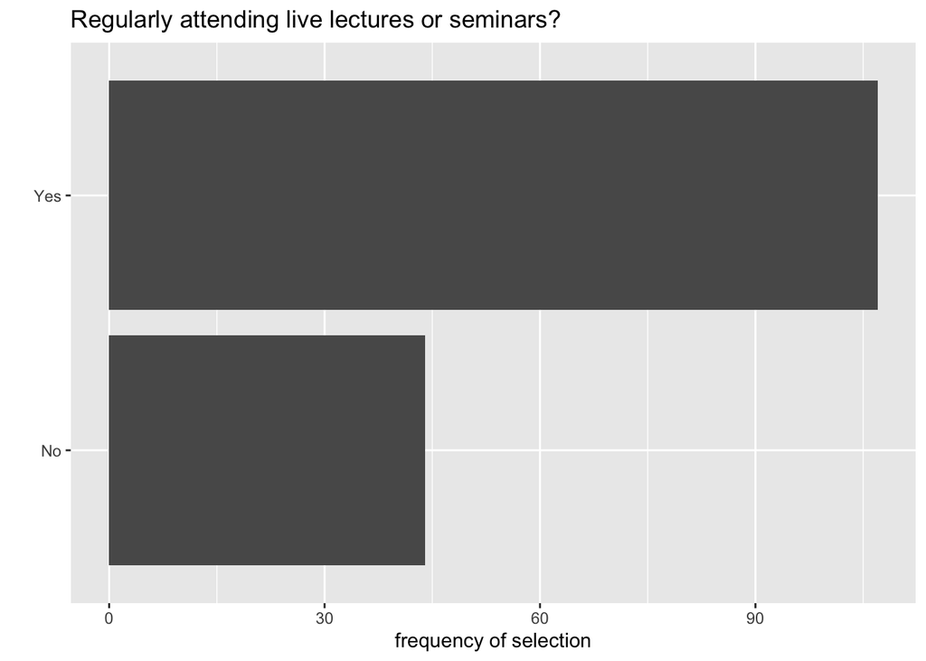

## Winter term 19/20 completed?

We asked:

> Have you been able to complete all your courses from the winter term?

Participants could choose between the two answers “Yes” and “No”. The distribution of answers is shown below.

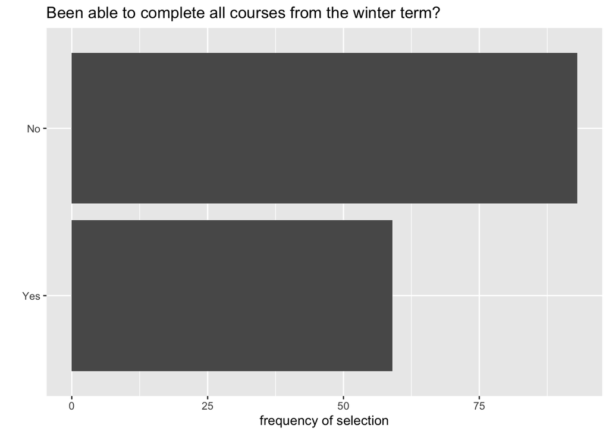

We also asked a follow-up:

> If you have no yet completed all of your courses from the winter term, do you already know when and how you will be able to complete these courses?

Participants could again choose between the two answers “Yes” and “No”. The distribution of answers is shown below.

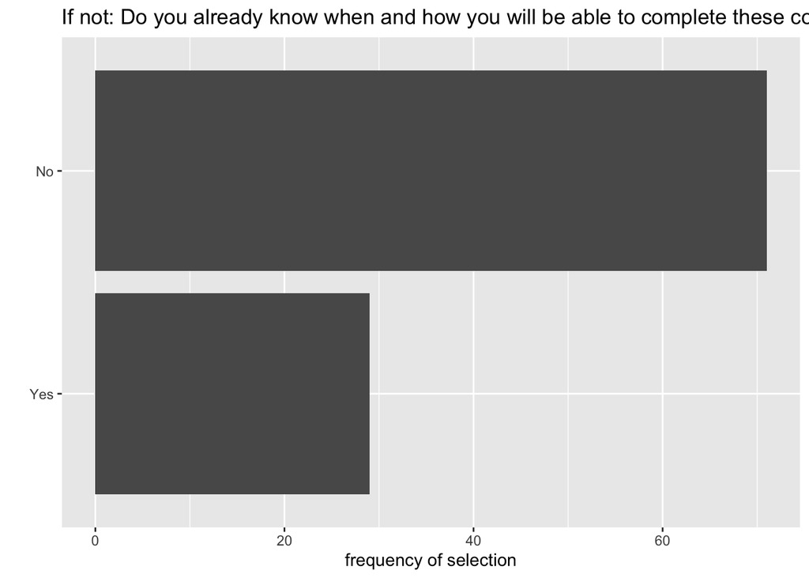

# 5. Social Life/Collaboration

In this section, we asked about how students organize their free time and collaboration with other students.

## Online study group meetings

We asked:

> How often do you arrange meetings with other people for studying?

Responses were:

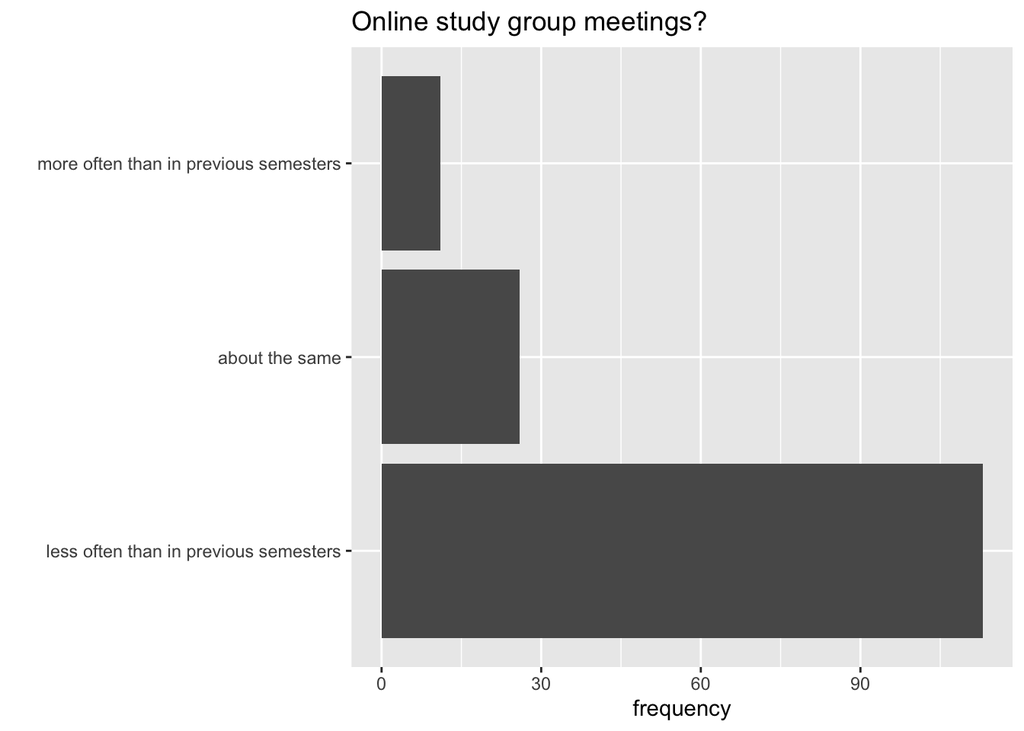

We also followed up:

> Do you meet virtually with people for studying?

Answers were:

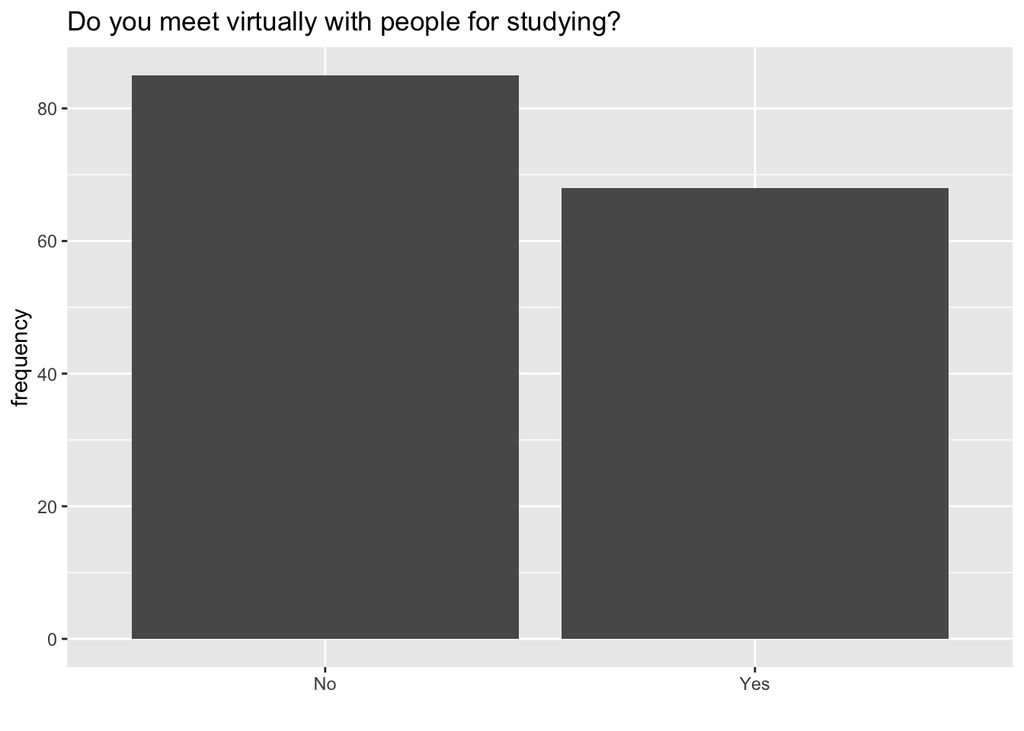

## Desire for online social activity

We asked:

> Would you wish there would be more online social events?

Answers were:

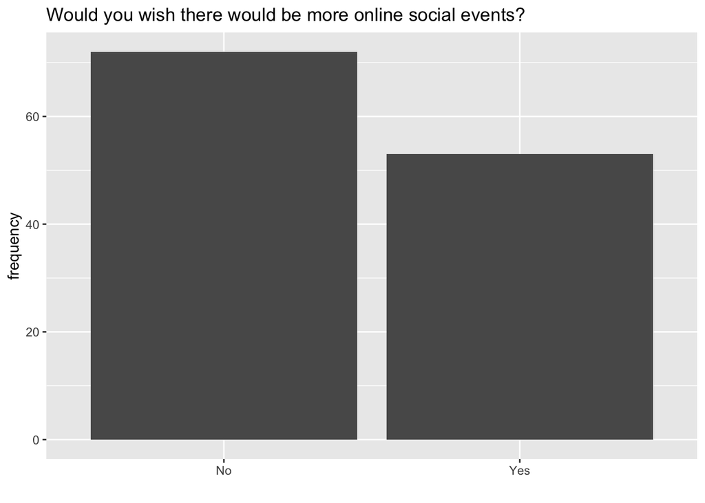

# 7. Final questions

## Who took this survey

We asked participants to give their study program and their semester.

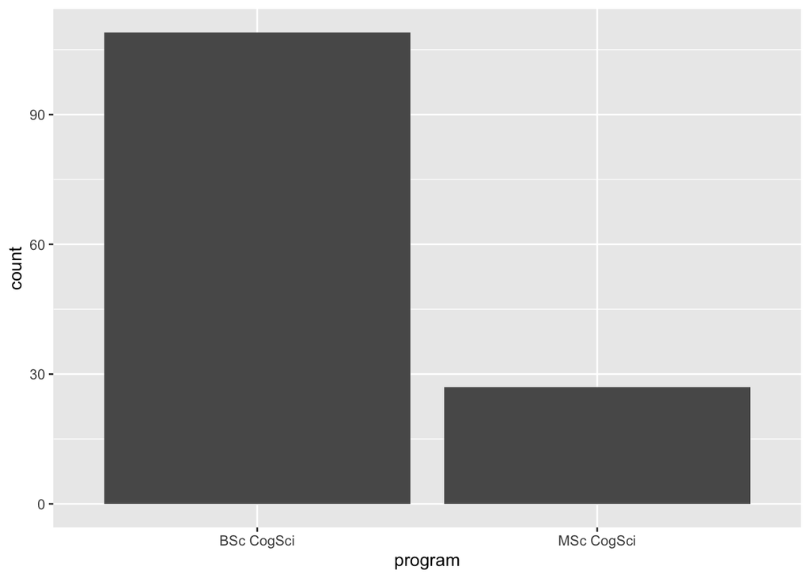

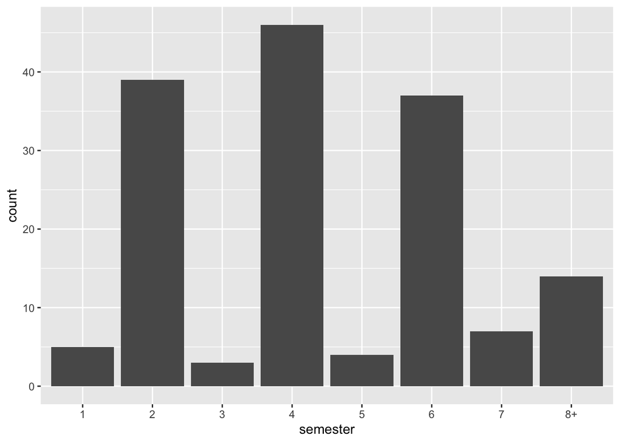

## Certainty about winter term

We asked:

> In case the next semester will be an online semester like the current, how important would it be for you to know this as soon as possible?

Here is the distribution of answers:

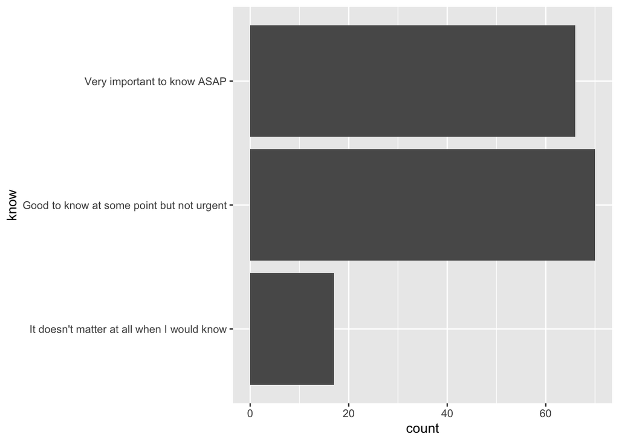

## Final remarks

We also encouraged to give any final remarks:

> Please share anything that so far you had no chance of mentioning!

Here is what was written:

1. Currently, the most important issue for me is the question how to organize my thesis in terms of supervisors and the topic. The Corona situation for me is the reason to consider writing with someone from the institute despite the obvious lack of linguists right now.
2. The situation at the Westerberg library is just hilarious! Hochschule students have access to study rooms, printers etc. and 25 people at the same time are allowed. University students in the same (!!!) library may not use any facilities, no printers, no study rooms and only 4(!) people are allowed in! This is just ridiculous and makes no sense… I really had feeling of being a second class citizen!!! — Furthermore: The situation to reach professors is not tolerable! I do know that Coxi professors are exceptionally busy and hard to reach, but normally when one needs something really urgent one can always find a lecture they are giving and catch them in the room… This is not possible now and I even have a friend who might get exmatriculated from the Master because her 2nd Superviser for the Bachelors Thesis refuses to reply to any emails since end of March and she can’t register her thesis because of this! Another friend who needs her final certificate is also into trouble because her supervising Professor did not even start to correct her thesis which she handed in beginning of March(!) and he does not reply to any emails or calls! This situation is not ok, the professors do have a responsibility towards us!
3. I am currently attending language lessons as well. Usually such lectures fill me with a lot of anxiety, but I feel better going about it with online lectures.
4. I am writing my thesis currently and just did one course in this digital semester, that is why I didn’t answer many of the questions, anyways I appreciated this questionnaire.
5. because of the online semster the university became more of a uneven playingfield, depending on which type of learner you are some are in a disatvantage
6. Just thanks for caring!
7. My online Courses are great and I feel like they don’t lack much in comparison to ‘normal’ courses (input-wise) but studying in groups on campus and motivating each other can hardly be replaced at the moment.
8. Every single questionnaire of this kind so far was biased towards assuming that the online semester made things worse. Many questions do not entertain the possibility that things might have improved. E.g. the responses to “If you suffer from any psychological conditions, did your situation worsen since March 2020?” does not offer an option for declaring that, on the contrary, my mental situation improved by a lot. People don’t seem to consider that previous conditions might not have been ideal for everybody involved, and that instead of “coping” with the current situation, some students may be rejoicing at the new opportunities given to them. — It is important to consider that, just as some students suffer under the new circumstances, others suffered under the old ones and it is only now that they can realize their full potential. I hope that after the pandemic passes the faculty as a whole won’t look back on the online semester as nothing more than an inconvenience, but as an opportunity to improve university life for everyone.
9. If I would not be free of anything else but my thesis for next semester, I would probably skip it as an holiday semester under the current conditions
10. It would be very helpful to get more information about the exams (from this semester and the last one). It makes it very difficult to make study plans when you don’t know when the exams will be happening and in which format
11. I hope that the online semester will still permit me to take my oral ‘Modulprüfung’, as I need it to sign up for my Bachelor’s Thesis in the sixth semester. Profs should refrain from making their courses more work-intense due to lack of organizational ideas for the exam.
12. You do a great job! Thanks! It is absolutely possible for me to have an enjoyable semester! – One further note is (exam) preparation. P reparation: one lecture had some issues with providing the lectures. I have the feeling this changes now, clear communication and maybe a switch to another media would have been appreciated anyways. The communication of the issues and how they will be handled by the course didn’t give me direction. — My personal note about exams: As to now I don’t know about the plans for exams. I’m getting a little nervous about not knowing the dates ;):) — I observe that I can handle “we are working on it to try to make it online” more indulging than “we are waiting & hoping for being able to do it offline” Thanks again for the charing work you all are putting in to make this work so extraordinary smooth;):);)
13. I like the way you are supporting us as Dean of studies, and think you do a great job.
14. I have the feeling that not all lecturers know how the technical stuff works even though they try their best. It might be a good idea to give them instructions about every function of StudIP so they do not feel lost. - Also it is really annoying to not know when exams are going to take place. This applies especially to the courses for the psychology students.
15. Selforganizing and discipline has been highly varying
16. I really hope that the next winter semester will be a normal semester as ‘usual’, or at least offers many smaller lectures and tutorial sessions to help students cope with the workload and isolation
17. Thanks to everyone who puts so much effort in this online semester and tries to make it work as best as possible! - Although this isnt a CogSci matter, I really would support to open libraries again. I know a lot of people, me included, who really need some other place to go for studying than your own little room in your shared flat. Motivating yourself at home is quite difficult and sitting in the same room all day long in the same chair, in front of your laptop is really exhausting.
18. Merely studying online is easier because I am not bound to lecture times anymore, thus I wish that, even if regular university is open again, all lectures and contents necessary to learn and pass the courses can be found on Stud.IP. This gives so much flexibility, because I am able to catch up with monday’s lecture content on a sunday, for instance, if time and work are more urgent for other courses.
19. Good work, guys.
20. I feel like a lot of lecturers could use some training in basic audio and video (screen) recording. Personally I have never done either of them but feel like I could do so better than a lot of the Profs currently. Just have a decent microphone (not expensive and could probably be provided by the university), a quiet room and record yourself giving the lecture to your laptop/computer screen while recording the powerpoint on your screen.
21. Overall I liked the online semester to be honest. It gave me the peace of mind I always wanted and present lectures are not that important to me. The financial problems kept me from concentrating on the learning materials and the crazy amount of workload was the most negative point. I also wish for some rule changes due to the credits we need to deliver till end of second semester and if we need extended time to finish.
22. Thank you for making efforts to make the online semester as accommodating as possible!
23. Many of my mental health issues are because of personal problems that are not really related to the online semester. What may be related, is that I don’t see my friends in person and my daily schedule is more compromised because I don’t have to get up and go to the campus.
24. because of Covid-19 some exams of the last semester have not taken place at all. Also some retake exams are only availabe now (partly during exam weeks of the current semester). One retake exam however will only be available during the third semester (AuD). This means that valuable ECTS are missing to achieve the 40 ECTS required to enter the third semester. Hopefully there will be an exception this time because of Covid-19.
25. Since I cannot meet my peers in the Mensa and overhear them talking, I am constantly feeling like I forgot something important, but I can not ask them because I don’t know what it could be. — Furthermore I feel anxious about online exams. What happens if the internet does not work during that time?
26. I am concerned about the 40 points mark to be allowed do continue stuying in the third semester. Due to canceled exams, the workload in the current semester is higher and the exam period is loaded. I hope to get enough points, but aren’t sure yet.
27. I wished I knew my fellow coxi master students! I have no clue about them, there wasn’t any introduction opportunity :/
28. A platform for just for contact/spontaneous talking when you’re not feeling well would be great; „outing“ as lonely is hard
29. I don’t like the way the online semester is structured (online courses, uncertainty of exams, no social life) and would like to have a normal semester for WS 20/21.
30. If the next semester is online, I will probably not take part in it as I am transitioning from the Bachelors to the masters program. Thinking about doing more than 15 ECTS like this, feels daunting to me. Studying only from home, without networking, seeing peers regularly without planning is essential for my study experience. Then again, I feel like I am working more efficiently, as distractions are reduced. I am glad, this is happening in the summer term, but in the winter term I fear that I won’t be able to follow through so easily.
31. I hope that some lecturers will rethink the way they teach their class and not just transfer it to online meetings. Often I feel like many lecturers only try to minimize their work by giving the same presentation topics to students every year and then neither providing additional input nor feedback for the students. This is not only a problem of the online semester, but in an online semester it strikes because additionally personal interaction is missing. On the other hand there are a few lecturers that really do a great job at teaching, providing lots of material, an interesting lecture, resources to exercises, provide feedback, use things like cliqr, etc. … I hope that in the future that will be the case in the majority of the classes.
32. If next sem is going to be online i think the course Designer should be provided with some extra knowledge about how to do it in better way. The course i found very well designed is Into to AI course
33. It would be really nice to know about this exam period, like dates, if online etc. Further the beginning and especially the ending of the WS is important, because I am planning an Erasmus semester next spring and if the WS will be shifted back, I could maybe not participate in the WS at all!
34. thank you for the great support and creativity during this time, I felt a lot of support
35. I think it would be a great idea for us as students during this “online learning” times to be able to access more online material that is out there. Not only regarding book but in general courses that are already “online learning” format friendly designed and would allow us to complete our studies. By that I mean platforms such as Edx, coursera, code Academy or the like which are already in the correct virtual format
36. Study rooms needed, even with it’s just for one person each. I think since it’s possible to register customers in bars or go to shops. There should be a solution possible that you can sign up or “book” rooms in the university, since they are probably empty
37. I really hope, the next semester is not completely online again. I would not understand this, because I think at least tutorials and other small events are okay. Also schools are opened. I have the feeling that it is easy to let the university happen online, because students were already independ before, so you kind of don’t see a big difference. But I can imagine that students, especially those which already struggled with the university, have a hard time with this.
38. I think it would be very helpful to get information about the exams from last semester and also the current semester as soon as possible, because I know a lot of people are struggeling to plan their summer if you need to work to finance your studies.
39. I love this online semester even though participating in info B is very stressful
40. I appreciate the online format of lectures, because one can go through the content in one’s own pace and make sure to understand everything by including pauses rather than always facing the impossible challenge of focussing for 90 minutes of new content input straight. But I really miss the social factor of studying, meeting fellow students and discussions with them (also about course-related stuff), and an opportunity to get personal help with concrete problems, e.g. course-specific digital infrastructure setup, which took me quite some time this semester. However, I guess I also learned a lot about how to solve arising problems on my own in this semester.
41. Please..don’t make another online semester.. please
42. Thanks for taking the time to do these surveys, helps a lot with not feeling left alone by the university.
43. In one of the first Mails it was mentioned, that the online semester will not be layed out to our disatvantage. I do not agree with that. First of all, the workload is still as high as in the semester before, despite this troublesome situation. I know that it is hard to make predictions e.g. regarding exam dates, but for working reasons in the semester break (because it is hard to get a job right now) it would be absolutetly crucial to know when exams will take place. Still in some courses there are still no dates for the 2. attempts or even for the 1. attempts. Also the retake exams are announced on very short notice, or are sheduled in the middle of my exam phase or on dates I already have to write another exam. Therefore I would have to write 6 exams, partially on the same day, in about 20 days. Since I do not have retake dates, it is not easy to shedule them to the retake dates. Because another probelm occuring is, that I still need my 40 ECT and some retakes are sheduled in the next semester. Additionally, learning for exams in groups and doing homework in groups is diffucult as well. Therefore I think this semester will very much be to my disatvantage.
44. Some professors really need to step up their “tech” game. Some slides look like the were made in 1999. Maybe because they were.
45. The reason for not knowing when to finish a course of the last semester is because it is suppose to be a written exam. As for this semester I have other courses which are suppose to have a written exam. It is not helping in the motivation and in time planing for the summer, that I have no idea when those exams will be held.
46. As I am “only” concerned with writing my Bachelor’s thesis at the moment, I do not really take too much notice of the ongoings with the students who do “real” courses at the moment and the struggles that they face. But I feel like the whole institute is very committed to solving problems and enabling and helping the students where possible. In my case, everyone is very understandable about the situation and the implications for my thesis.
47. I like that i can choose when to watch most of the lectures. It actually feels way better than last semester.
48. The most difficult thing is being in the same space (i e at home) for both work and private life - work takes over 100% of the time.
49. After the experience of this semester, I wish that all semesters could also be offered online. I found out that home office and online semester is more productive for me and for some courses definitely online works better. So at least offering some online courses in a non covid 19 situation semester could be a good idea in my opinion because for instance for me it would be great because I also have to work and finance myself and don’t have too much time to spare and online courses help me a lot to finish my studies sooner.
50. Thanks for all the work that the professors and tutors are doing right now! ^^
51. half tutorials online, half not online. People who don’t wanna /cannot risk will not have to. That’d be cool for everyone. But please, exams not online. Maybe orally if too many people cannot be in the same room.
52. I wished I knew my fellow coxi master students! I have no clue about them, there wasn’t any introduction opportunity :/
53. Obviously, this semester is not like any of us imagined and there are many hardships to be faced. However, I really feel like this situation highlights how well connected and mutually supportive the entire Coxi community is. It makes this awkward time much more bearable. I also feel like the courses that work best are the ones where communication between lecturers and students runs most freely. A lot of frustration (on both sides I assume) can be prevented when underlying issues are made transparent by the lecturer and when students feel like their suggestions are heard.
54. I’m quite concerned about the 40 ECTS mark that you have to fulfill during the first two semesters of the bachelors program as I e.g. didn’t have the chance to finish some of the courses from last semester (math and informatics) which led me to take quite a lot of courses this semester (and due to that I’m pretty stressed out) as I’m afraid to have to little ECTS by the end of the second semester.
55. i admire the german people for how they have not compromised on learning despite the conditions